# Analysis of Population Dynamics by Age Groups and Regions

## 1.3 Data Preparation

This section describes the steps to preprocess and organise the data, including cleaning, transforming, and categorising variables. It ensures the data-set’s readiness for analysis and aligns with the research objectives.

```r
#
# Load the dataset.
#
fp1 <- here("Data", "population-young-working-elderly.csv")

#
# Load the Population Young Working Elderly CSV file.
#
d1 <- read_csv(fp1, show_col_types = FALSE)

# rename column variables of d1
d1 <- d1 %>%
   rename(
    Population_65plus = `Population - Sex: all - Age: 65+ - Variant: estimates`,
    Population_15to64 = `Population - Sex: all - Age: 15-64 - Variant: estimates`,
    Population_0to14 = `Population - Sex: all - Age: 0-14 - Variant: estimates`
  )

#
# Set the relative file path (assuming the file is in the 'Data' directory).
# Use here() to specify the relative file path using the root of the R project
# (where the .Rproj file is located).
#
fp2 <- here("Data", "Gender_education_area2015_2022.csv")

#
# Load the Gender Education csv.
#
d2 <- read_csv(fp2, show_col_types = FALSE)

#
# Vector of the required columns (Author: Vince Currie).
#
sc2 <- c("Reference area",
         "Education level",
         "Field of education",
         "Sex",
         "OBS_VALUE")

#
# The following steps are undertaken (Author: Vince Currie):
#    Rename the column names to something more meaningful.
#    Obtain the mean percentage by gender category for country, education level and field using group by and summarise.
#    Turn the gender category into columns with the calculated means using pivot: giving "Total" and "Female" columns.
#    Calculate the "Male" %  using mutate to create the column as Male = Total - Female. The coalesce replaces NA with 0.
#
#
 rn2 <- d2[, sc2] %>%
    rename(Cntry = "Reference area",           # Country.
           Edctn_lvl = "Education level",      # Education Level.
           Fld = "Field of education",         # Field.
           Gndr_ctgry = "Sex",                 # Gender Category (Values: Female and Total)
           Obsrvtn_vl = "OBS_VALUE")  %>%      # Percentage. For example, percentage of female participation.
    group_by(Cntry, Edctn_lvl, Fld, Gndr_ctgry)  %>%
    summarise(mObsrvtn_vl = mean(Obsrvtn_vl,na.rm = TRUE),.groups = "drop") %>%
    pivot_wider(names_from = Gndr_ctgry, values_from = mObsrvtn_vl) %>%
    mutate(Male = coalesce(Total,0) - coalesce(Female,0))

#
# Define a vector of STEM-related keywords to search for to classify field as stem or not (Author: Vince Currie).
#
 stem_keywords <- c("Science", "Technology", "Engineering", "Mathematics", "ICT", "Veterinary")

#
# Add a new column 'STEM_Status' categorizing as 'STEM' or 'OTHER' (Author: Vince Currie).
#    Exclude "Total (excluding unknown)" as its not a discipline.
#    Add STEM_Status to the data frame using mutate:
#       * Collapse stem_keywords down to a string of "or" cases using paste and collapse keyword.
#       * Search the "Fld" column looking for a stem keyword in each row using "grepl" command, ignoring case.
#       *   If a stem keyword is found, assign the STEM_Status column the value "STEM",
#       *   else assign the STEM_Status column the value "OTHER" using the "case_when" command.
#       *   Make the special case of "Social sciences" "OTHER" as its not part of stem but "science" is in the name.
#    Change the STEM_Status column to categorical using mutate and,
#    Calculate the Gender Gap which is the difference between Male and Female percentages working in that field:
#       If the Gender Gap is positive, it means that Males are dominant in the field,
#       else it means that females are dominant if the field for Gender Gap < 0.
#
rn2 <- rn2 %>%
  filter(Fld != "Total (excluding unknown)") %>%
  mutate(STEM_Status = case_when(
    grepl(paste(stem_keywords, collapse = "|"), Fld, ignore.case = TRUE) &
    !grepl("social science|arts|humanities", Fld, ignore.case = TRUE) ~ "STEM",
    TRUE ~ "OTHER"
  )) %>%
  mutate(STEM_Status = factor(STEM_Status),
         Gender_Gap = round(coalesce(Male,0) - coalesce(Female,0),2))

#
# Get the unique field areas being compared as part of Gender Gap (Author: Vince Currie).
#
unique_fields <- unique(rn2$Fld)

#
# Convert the unique fields into a data frame for display as a formatted table (Author: Vince Currie).
#
unique_fields_df <- data.frame(FieldArea = unique_fields)

#
# Rename the column from 'FieldArea' to 'Field Area' (Author: Vince Currie).
#
colnames(unique_fields_df)[colnames(unique_fields_df) == "FieldArea"] <- "Field Area"

#
# Calculate the summary statistics for gender gap by grouping by STEM_Status (Author: Vince Currie).
# Apply multiple summary functions to 'Gender_Gap' using across within summarise.
#   * ".x" represents the value of "Gender_Gap".
#   * ".names = "{.fn}_Gender_Gap" creates the columns as Lower_Gender_Gap, and so on.
#   * The results are rounded to 2 decimal places using round.
#   * The Lower and Upper are capped at -100 and 100 using pmin and pmax. There's only 100% of something.
#
summary_stats <- rn2 %>%
  group_by(STEM_Status) %>%
  summarise(
    across(
      Gender_Gap,
      list(
        Lower = ~round(pmax(min(.x, na.rm = TRUE), -100), 2),  # Ensure min is capped at -100
        Upper = ~round(pmin(max(.x, na.rm = TRUE), 100), 2),   # Ensure max is capped at 100
        Median = ~round(median(.x, na.rm = TRUE), 2),
        Mean = ~round(mean(.x, na.rm = TRUE), 2)
      ),
      .names = "{.fn}_Gender_Gap"
    )
  )

#
# Calculate Q1 (25%) and Q3 (75%) for Gender_Gap grouped by STEM_Status (Author: Vince Currie).
#
iqr_stats <- rn2 %>%
  group_by(STEM_Status) %>%
  summarise(
    Q1 = round(quantile(Gender_Gap, 0.25, na.rm = TRUE),2),
    Q3 = round(quantile(Gender_Gap, 0.75, na.rm = TRUE),2)
  )

#
# Australia only rows for visualising the Australia data (Author: Vince Currie):
#   * Filter the Australian data.
#   * Select the required columns.
australia_data <- rn2 %>%
  filter(Cntry == "Australia") %>%
  select(Cntry, Edctn_lvl, Fld, STEM_Status, Gender_Gap)

#
# Australia data table (Author: Vince Currie).
#   * Rename columns for display in table.
#   * Select the fields.
#   * Sort the data by Field and Education_Level using arrange.
#   * Display Field once per group using lag and mutate.
#
# The table is used to augment the figure by showing those
# rows where the gender gap is close to parity (|Gender Gap| <= 1).
#
australia_tab <- australia_data %>%
  rename(Field = Fld,
         Level = Edctn_lvl,
         `Gender Gap` = Gender_Gap,
         `Stem Status` = STEM_Status) %>%
  arrange(`Stem Status`, Field, Level) %>%
  mutate(
    Field = ifelse(is.na(lag(Field)) | lag(Field) != Field, Field, "")
  ) %>%
  filter(abs(`Gender Gap`) <= 1) %>%
  select( Field, `Stem Status`, Level, `Gender Gap`)
```

# 2 Visualisation

The visualisation section presents key insights through graphs and charts, illustrating gender gaps across education levels, fields, and regions. It highlights disparities in STEM and non-STEM fields, global trends, and Australia’s context. These visualisations enhance understanding by showcasing patterns, variability, and progress toward achieving gender parity in education.

## 2.1 Visualisation - Dhanya

Figure 2.1: Population Aged 65+ for Selected countries (1950-2020) - (Author:Dhanya)

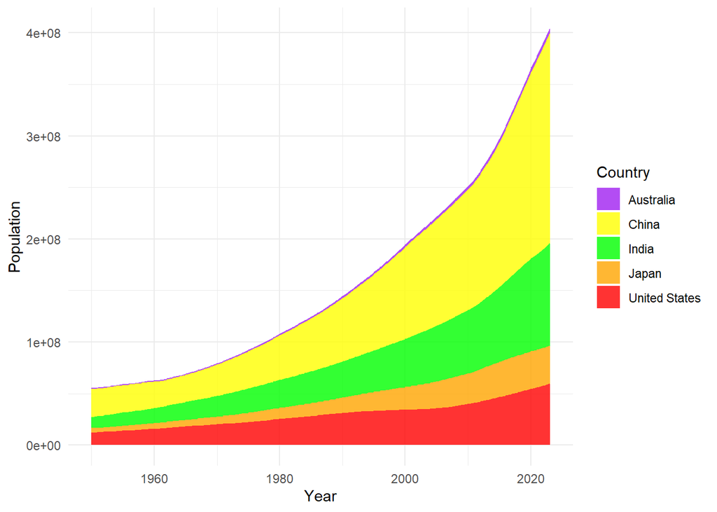

```r
# Define countries to highlight
highlight_countries <- c("United States", "China", "India", "Australia", "Japan")

# Filter data for highlighted countries
# VC: highlighted_data <- data %>% filter(Entity %in% highlight_countries)
highlighted_data <- d1 %>% filter(Entity %in% highlight_countries)

# Create the stacked area chart
ggplot(highlighted_data, aes(x = Year, y = Population_65plus, fill = Entity)) +
  geom_area(alpha = 0.8) +  # Use geom_area for stacked chart
  labs(x = "Year",
       y = "Population",
       fill = "Country") +
  theme_minimal() +
  scale_fill_manual(values = c(
    "United States" = "red",
    "China" = "yellow",
    "India" = "green",
    "Australia" = "purple",
    "Japan" = "orange"
  ))
```

```r
# Define countries to include
selected_countries <- c("United States", "China", "India", "Australia", "Japan")

# Filter data for the selected countries
# VC: filtered_data <- data %>%
filtered_data <- d1 %>%
  filter(Entity %in% selected_countries) %>%
  group_by(Entity, Year) %>%
  summarise(Population_0to14 = sum(Population_0to14, na.rm = TRUE))
```

Figure 2.2: Population Aged 0-14 for Selected Countries (1950-2020) - (Author:Dhanya)

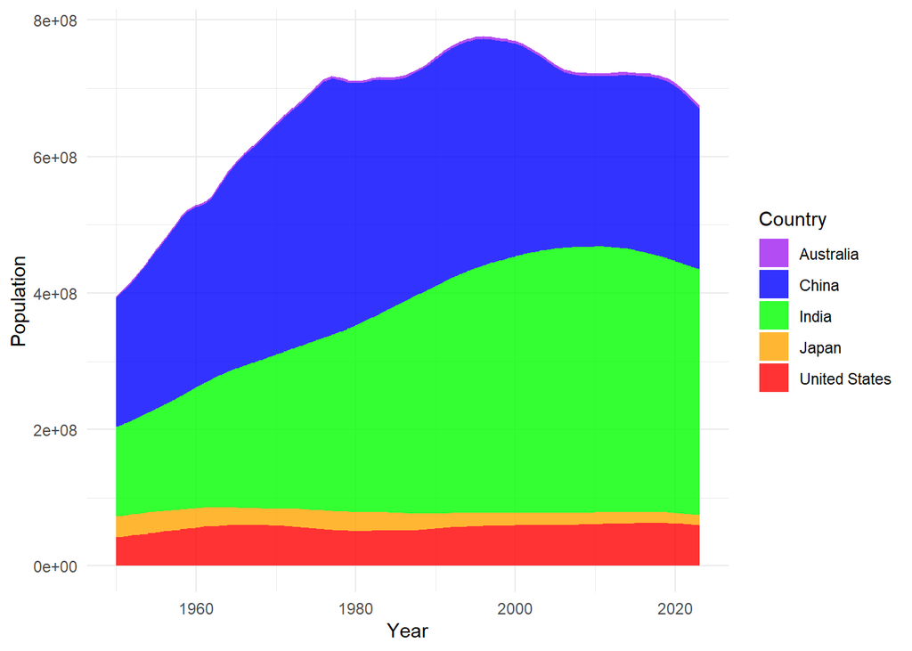

```r
# Create the stacked area chart
ggplot(filtered_data, aes(x = Year, y = Population_0to14, fill = Entity)) +
  geom_area(alpha = 0.8) +  # Stacked area chart
  labs(x = "Year",
       y = "Population",
       fill = "Country") +
  theme_minimal() +
  scale_fill_manual(values = c(
    "United States" = "red",
    "China" = "blue",
    "India" = "green",
    "Australia" = "purple",
    "Japan" = "orange"
  ))
```

## 2.2 Visualisation - Vince Currie

Figure 2.3: World STEM Gender Gap(%)  
(Based on 2015-2022 Data) - (Author: Vince Currie)

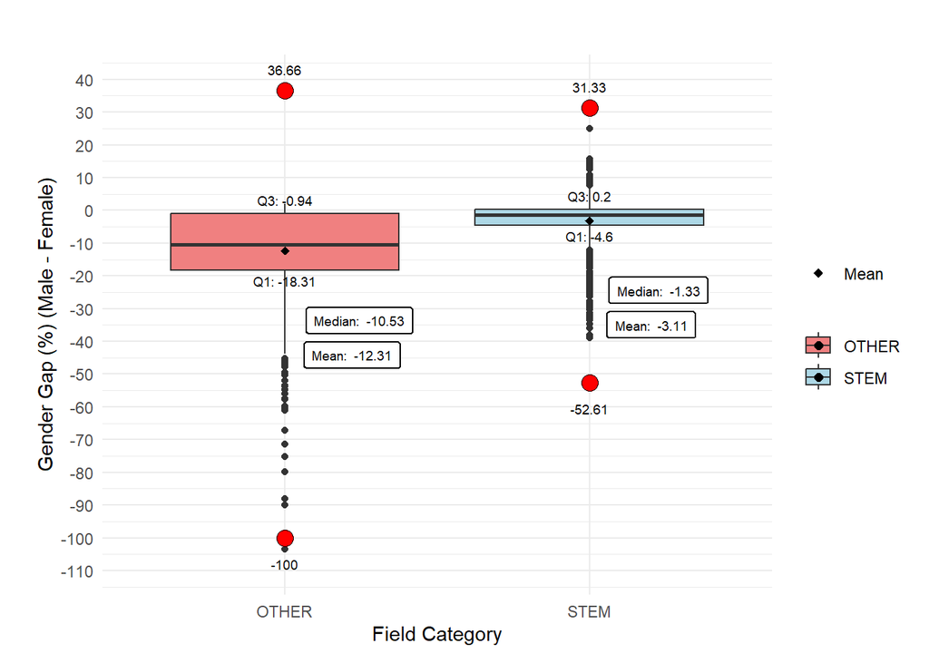

```r
#
# Visualize the gender gap for STEM and non-STEM Vocations using a box plot with "geom_boxplot".
#
ggplot(rn2, aes(x = STEM_Status, y = Gender_Gap, fill = STEM_Status)) +
  geom_boxplot() +

  # Display a circle at the lower and upper ends of the whiskers.
  geom_point(
    data = summary_stats,
    aes(x = STEM_Status, y = Lower_Gender_Gap),
    shape = 21,
    fill = "red",
    size = 4
  ) +
  geom_point(
    data = summary_stats,
    aes(x = STEM_Status, y = Upper_Gender_Gap),
    shape = 21,
    fill = "red",
    size = 4
  ) +

  # Display the lower and upper values.
  geom_text(
    data = summary_stats,
    aes(x = STEM_Status, y = Lower_Gender_Gap, label = Lower_Gender_Gap),
    vjust = 3,
    size = 2.5
  ) +
  geom_text(
    data = summary_stats,
    aes(x = STEM_Status, y = Upper_Gender_Gap, label = Upper_Gender_Gap),
    vjust = -1.5,
    size = 2.5
  ) +

  # Display the middle 50%.
geom_text(
  data = iqr_stats,
  aes(x = STEM_Status, y = Q1, label = paste("Q1:", round(Q1, 2))),
  hjust = 0.5,                                # Centre horizontally above the bar.
  vjust = 1.5,                                # Adjust vertically to avoid overlap.
  color = "black", size = 2.5
) +
geom_text(
  data = iqr_stats,
  aes(x = STEM_Status, y = Q3, label = paste("Q3:", round(Q3, 2))),
  hjust = 0.5,                                # Centre horizontally above the bar.
  vjust = -0.8,                               # Adjust vertically to avoid overlap.
  color = "black", size = 2.5
) +

  # Add mean value diamond.
  geom_point(
    data = summary_stats,
    aes(x = STEM_Status, y = Mean_Gender_Gap, shape = "Mean"),
    size = 2,
    color = "black"
  ) +

  labs(x = "Field Category", y = "Gender Gap (%) (Male - Female)") +

  # A legend for the mean value.
  scale_shape_manual(name = "Statistics", values = c("Mean" = 18)) +
  theme_minimal() +

  # Add call out boxes for the mean and median.
  geom_label(data = summary_stats,
             aes(x = STEM_Status, y = Mean_Gender_Gap, label = paste("Mean: ", round(Mean_Gender_Gap, 2))),
             color = "black", size = 2.5, label.padding = unit(0.5, "lines"), label.size = 0.5,
             vjust = 4.5, hjust = -0.2, fill = "white") +  # White background for the call out label.
  geom_label(data = summary_stats,
             aes(x = STEM_Status, y = Median_Gender_Gap, label = paste("Median: ", round(Median_Gender_Gap, 2))),
             color = "black", size = 2.5, label.padding = unit(0.5, "lines"), label.size = 0.5,
             vjust = 3.4, hjust = -0.2, fill = "white") +  # White background for the call out label.

  scale_fill_manual(values = c("STEM" = "lightblue", "OTHER" = "lightcoral")) +
  theme(legend.title = element_blank()) +
  scale_y_continuous(breaks = seq(-110, 40, by = 10)) +  # Adjust y-axis ticks.
  expand_limits(y = c(40,-110)) +                        # Ensure that the plot expands to y = (-110,40).

  theme(legend.title = element_blank(),
    plot.margin = margin(t = 30, r = 10, b = 10, l = 20)
        )
```

Figure 2.4: Gender Gap in STEM Education  
by  
Field and Level in Australia (2015–2022) - (Author: Vince Currie)

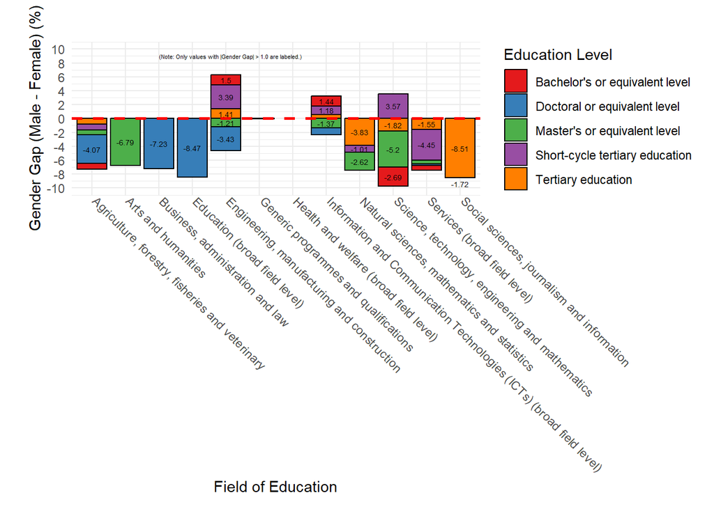

```r
#
# Create a bar chart for Australian STEM education.
# (Useful information on colour: : https://www.r-bloggers.com/2013/09/how-to-expand-color-palette-with-ggplot-and-rcolorbrewer/).
#
ggplot(australia_data, aes(x = Fld, y = Gender_Gap, fill = Edctn_lvl)) +
  geom_bar(stat = "identity", position = "stack", color = "black") +         # Use position = "stack" for stacking.
  scale_fill_brewer(palette = "Set1") +                                      # Distinct colours for education levels.
  geom_hline(yintercept = 0, color = "red", linetype = "dashed", size = 1) + # Add parity line.
  scale_y_continuous(
    limits = c(-10, 10),
    breaks = seq(-10, 10, by = 2)                                            # Add more y-axis ticks.
  ) +
  geom_text(
   aes(
    label = ifelse(abs(Gender_Gap) > 1.0, round(Gender_Gap, 2), "")          # Display label only if Gender_Gap > 1.0.
  ),
  position = position_stack(vjust = 0.5),                                    # Centre labels within segments.
  size = 1.8,
  color = "black"
)+
  annotate(
    "text",
    x = 3, y = 9,                                                            # Adjust the x and y positions.
    label = "(Note: Only values with |Gender Gap| > 1.0 are labeled.)",
    size = 1.5,
    hjust = 0,                                                               # Align text horizontally.
    color = "black"
  )+
  labs(
    x = "Field of Education",
    y = "Gender Gap (Male - Female) (%)",
    fill = "Education Level"
  ) +
  theme_minimal() +
  theme(
    axis.text.x = element_text(
      angle = -45,
      hjust = 0,
      vjust = 0
    ),
    plot.margin = margin(t = 30, r = 10, b = 10, l = 20)
  )
```

## 2.3 Visualisation - Bailey Dalton

Figure 2.5: Population growth across continents from 1950 to 2020 - (Author: Bailey Dalton)

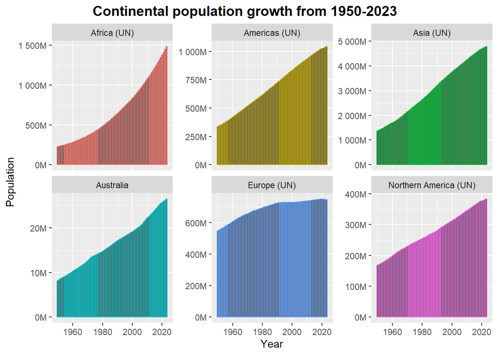

```r
Continent_data <- d1 %>%
  filter(Entity %in% c("Africa (UN)",
                       "Americas (UN)",
                       "Asia (UN)",
                       "Europe (UN)",
                       "Northern America (UN)",
                       "Australia")) %>%
  mutate(Population = Population_65plus + Population_15to64 + Population_0to14)

ggplot(Continent_data, aes(x = Year, y = Population, color = Entity)) +
  geom_col() +
  facet_wrap(~ Entity, scales ="free_y") +
  theme(legend.position = "none") +
  scale_y_continuous(labels = label_number(scale = 1e-6, suffix = "M")) +
  labs(
    title = "Continental population growth from 1950-2023",
    x = "Year",
    y = "Population",
  ) +
  theme(
    plot.title = element_text(size = 14, face = "bold", hjust = 0.3)
    )
```

Figure 2.6: Population growth trends across economic regions and age groups - (Author: Bailey Dalton)

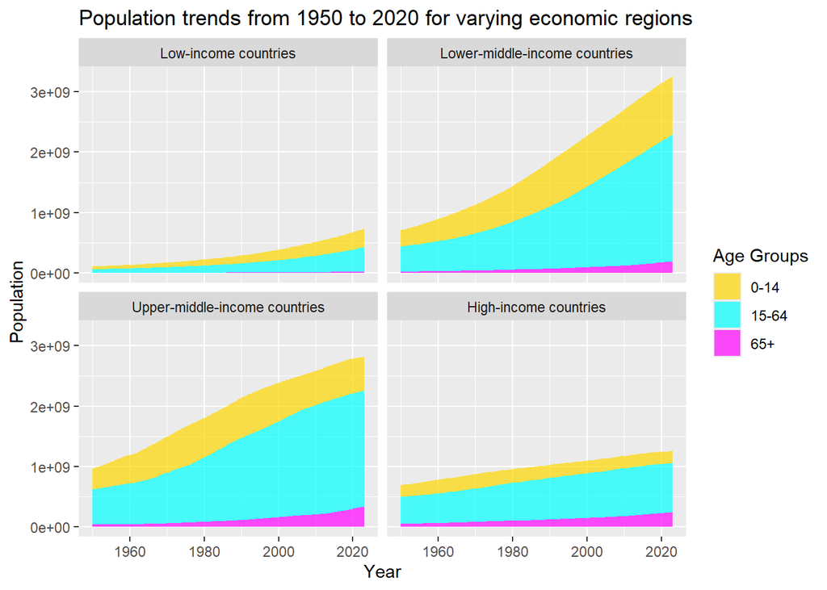

```r
# create data frame for population dev data (socioeco status regions) from data
Population_DevelopmentData <- d1 %>%
  filter(Entity %in% c("Low-income countries",
                       "Lower-middle-income countries",
                       "Upper-middle-income countries",
                       "High-income countries"
                       )) %>%
  # rename age group columns for convenience
  rename(
    "65+" = Population_65plus,
    "15-64" = Population_15to64,
    "0-14" = Population_0to14,
    "Socio_Economic_Status" = Entity
  ) %>%
  # gather data to get it in the correct shape
  gather(AgeGroup, Population, "65+", "15-64", "0-14") %>%
  select(!Code) %>%
  mutate(Socio_Economic_Status = factor(Socio_Economic_Status,
         levels = c("Low-income countries",
                    "Lower-middle-income countries",
                    "Upper-middle-income countries",
                    "High-income countries")))

# Create socio economic plot with formatting
ggplot(Population_DevelopmentData, aes(x = Year, y = Population, fill = AgeGroup)) +
  geom_area(alpha = 0.7) +
  facet_wrap(~ Socio_Economic_Status, nrow = 2) +
  labs(title = "Population trends from 1950 to 2020 for varying economic regions",
       x = "Year",
       y = "Population",
       fill = "Age Groups") +
  scale_fill_manual(values = c(
    "0-14" = "gold",
    "15-64" = "cyan",
    "65+" = "magenta"
  ))
```